# Analysis of Framingham BMD data

## The idea

We have two cohorts, denoted *original* and *offspring*, that are followed over time. For each cohort, bone mineral density (BMD) is measured 3 times. We are interested in seeing how the BMD changes ecologically over time, hopefully in inverse relation to the known prevalence changes in hip fractures over time.

The assessment of BMD change has to be adjusted for subject age, since the biggest factor for reduction in BMD is age. The first analysis proposes to merge the original and offspring cohorts and use the full data to model the change in BMD over time adjusted for age (or age groups). We'll split the ages up by decade.

```python
import numpy as np
import pandas as pd
import statsmodels.api as sm
import statsmodels.formula.api as smf
import matplotlib.pyplot as plt
import seaborn as sns

%matplotlib inline
```

```python
original = pd.read_excel('cohortBMD_newID2.XLSX')[['newid','SEX','scdt','Exam','age','year_of_birth','TScore']]
offspring = pd.read_excel('offspringBMD_newID2.xlsx')[['newID','SEX','scdt','Exam','age','year_of_birth','TScore']]
original.columns = map(str.lower, original.columns)
offspring.columns = map(str.lower, offspring.columns)
original['cohort'] = 'original'
offspring['cohort'] = 'offspring'

full_data = pd.concat([original, offspring], ignore_index=True, axis=0)
full_data.head()
```

|  | newid | sex | scdt | exam | age | year_of_birth | tscore | cohort |
| --- | --- | --- | --- | --- | --- | --- | --- | --- |
| 0 | 1976 | 2 | 1988-01-21 | 20.0 | 78 | 1910 | -2.190256 | original |
| 1 | 2052 | 2 | 1988-01-14 | 20.0 | 75 | 1913 | -2.830245 | original |
| 2 | 2090 | 1 | 1988-01-07 | 20.0 | 74 | 1914 | 1.727634 | original |
| 3 | 2128 | 1 | 1988-01-11 | 20.0 | 78 | 1910 | -2.543687 | original |
| 4 | 2147 | 1 | 1988-01-12 | 20.0 | 72 | 1916 | -1.795316 | original |

We now create some categories for age and time. In particular, we split ages into groups <= 50, 51-60, 61-70, 71-80, 80 and above, and time into half-decades. The following table gives the mean t-score per age/time combination, and the subsequent table gives the frequencies (number of subjects) per age/time combination

```python
full_data['age_groups'] = pd.cut(full_data.age, [30,50, 60,70, 80, 101])
full_data['exam_year'] = pd.DatetimeIndex(full_data['scdt']).year
full_data['half_decs'] = pd.cut(full_data.exam_year, range(1985,2011, 5))
bl = full_data.groupby(['half_decs','age_groups'], as_index=False)['tscore'].mean()
bl2 = bl.pivot(columns='half_decs', index = 'age_groups', values='tscore')
bl2
```

| half_decs age_groups | (1985, 1990] | (1990, 1995] | (1995, 2000] | (2000, 2005] | (2005, 2010] |
| --- | --- | --- | --- | --- | --- |
| (30, 50] | NaN | NaN | -0.366485 | -0.269697 | -0.208673 |
| (50, 60] | NaN | NaN | -0.723040 | -0.642317 | -0.702922 |
| (60, 70] | -1.536242 | NaN | -1.084437 | -0.844818 | -0.838831 |
| (70, 80] | -1.896947 | -1.853398 | -1.597161 | -1.266296 | -1.168521 |
| (80, 101] | -2.199488 | -2.338025 | -2.184395 | -1.575464 | -1.639977 |

```python
pd.crosstab(full_data.age_groups, full_data.half_decs)
```

| half_decs age_groups | (1985, 1990] | (1990, 1995] | (1995, 2000] | (2000, 2005] | (2005, 2010] |
| --- | --- | --- | --- | --- | --- |
| (30, 50] | 0 | 0 | 465 | 105 | 45 |
| (50, 60] | 0 | 0 | 1082 | 521 | 414 |
| (60, 70] | 215 | 0 | 918 | 574 | 673 |
| (70, 80] | 729 | 677 | 756 | 341 | 449 |
| (80, 101] | 190 | 259 | 328 | 34 | 102 |

The pattern of average t-scores by age and time is more evident in the figure below.

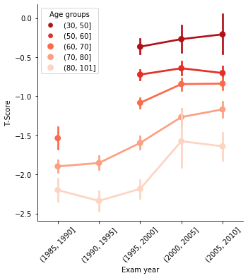

```python
fig = sns.catplot(data=full_data, x = 'half_decs', y ='tscore', hue = 'age_groups',
                  kind='point', legend=False, palette='Reds_r');
plt.xlabel('Exam year');
plt.ylabel('T-Score');
plt.xticks(rotation=45);
plt.legend(title='Age groups');
```

We can do a bit of modeling using OLS regression to quantify gross patterns in the t-scores. We will model the t-scores on age groups and time intervals.

```python
full_data1 = full_data.copy()
full_data1['age_groups'] = full_data1.age_groups.astype(str)
full_data1['half_decs'] = full_data1.half_decs.astype(str)
model = smf.ols('tscore ~ age_groups + half_decs', data=full_data1)
model.fit().summary()
```

OLS Regression Results

| Dep. Variable: | tscore | R-squared: | 0.221 |
| --- | --- | --- | --- |
| Model: | OLS | Adj. R-squared: | 0.220 |
| Method: | Least Squares | F-statistic: | 312.5 |
| Date: | Wed, 22 Jan 2020 | Prob (F-statistic): | 0.00 |
| Time: | 11:47:50 | Log-Likelihood: | -12850. |
| No. Observations: | 8812 | AIC: | 2.572e+04 |
| Df Residuals: | 8803 | BIC: | 2.578e+04 |
| Df Model: | 8 |  |  |
| Covariance Type: | nonrobust |  |  |

|  | coef | std err | t | P>\|t\| | [0.025 | 0.975] |
| --- | --- | --- | --- | --- | --- | --- |
| Intercept | -0.7465 | 0.056 | -13.295 | 0.000 | -0.857 | -0.636 |
| age_groups[T.(50.0, 60.0]] | -0.4115 | 0.048 | -8.525 | 0.000 | -0.506 | -0.317 |
| age_groups[T.(60.0, 70.0]] | -0.6950 | 0.048 | -14.481 | 0.000 | -0.789 | -0.601 |
| age_groups[T.(70.0, 80.0]] | -1.1340 | 0.049 | -23.167 | 0.000 | -1.230 | -1.038 |
| age_groups[T.(80.0, 101.0]] | -1.6235 | 0.057 | -28.500 | 0.000 | -1.735 | -1.512 |
| half_decs[T.(1990, 1995]] | 0.0285 | 0.047 | 0.606 | 0.544 | -0.064 | 0.120 |
| half_decs[T.(1995, 2000]] | 0.3528 | 0.039 | 9.099 | 0.000 | 0.277 | 0.429 |
| half_decs[T.(2000, 2005]] | 0.5700 | 0.044 | 13.040 | 0.000 | 0.484 | 0.656 |
| half_decs[T.(2005, 2010]] | 0.6015 | 0.042 | 14.212 | 0.000 | 0.519 | 0.684 |

| Omnibus: | 1007.441 | Durbin-Watson: | 1.362 |
| --- | --- | --- | --- |
| Prob(Omnibus): | 0.000 | Jarque-Bera (JB): | 2345.453 |
| Skew: | 0.683 | Prob(JB): | 0.00 |
| Kurtosis: | 5.126 | Cond. No. | 11.6 |

Warnings:  
[1] Standard Errors assume that the covariance matrix of the errors is correctly specified.

## Influence of gender

[figure not shown]

```python
plot_data = full_data.copy()
plot_data['sex'] = plot_data.sex.replace({1:'Male', 2:'Female'})
fig = sns.catplot(data=plot_data, col='sex', x = 'half_decs', y = 'tscore', hue = 'age_groups',
                  kind='point', legend=False, palette='Reds_r')
plt.legend(title='Age groups');
for ax in fig.axes.flat:
    ax.set_xlabel('Exam year')
    #ax.set_ylabel('T-score')
    for label in ax.get_xticklabels():
        label.set_rotation(45)
fig.axes[0,0].set_ylabel('T-score');
```

```python
model2 = smf.ols('tscore ~ age_groups*sex + half_decs*sex ', data=full_data)
results = model2.fit()
table = sm.stats.anova_lm(results)
table
```

|  | df | sum_sq | mean_sq | F | PR(>F) |
| --- | --- | --- | --- | --- | --- |
| age_groups | 4.0 | 2381.681904 | 595.420476 | 667.790867 | 0.000000e+00 |
| half_decs | 4.0 | 325.587048 | 81.396762 | 91.290133 | 3.587074e-76 |
| sex | 1.0 | 1573.513557 | 1573.513557 | 1764.766287 | 0.000000e+00 |
| age_groups:sex | 4.0 | 96.022872 | 24.005718 | 26.923493 | 3.094201e-22 |
| half_decs:sex | 4.0 | 21.638369 | 5.409592 | 6.067101 | 7.157132e-05 |
| Residual | 8794.0 | 7840.969270 | 0.891627 | NaN | NaN |

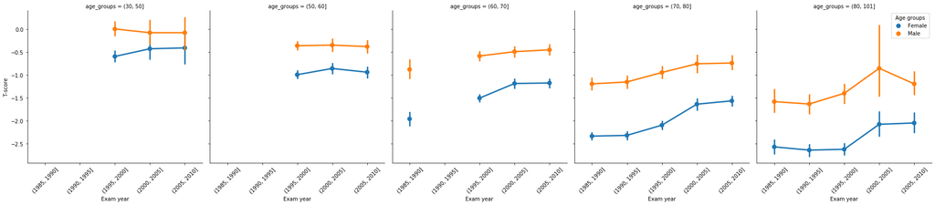

```python
plot_data = full_data.copy()
plot_data['sex'] = plot_data.sex.replace({1:'Male', 2:'Female'})
fig = sns.catplot(data=plot_data, col='age_groups', x = 'half_decs', y = 'tscore', hue = 'sex', kind='point', legend=False)
plt.legend(title='Age groups');
for ax in fig.axes.flat:
    ax.set_xlabel('Exam year')
    #ax.set_ylabel('T-score')
    for label in ax.get_xticklabels():
        label.set_rotation(45)
fig.axes[0,0].set_ylabel('T-score');
```

## Individual variation

I'm trying to see how the trajectories of t-scores within individuals looks like. Generally, the offspring are in better shape than the original cohort, and as you've said, the scores are relatively stable, though some do fall. See below

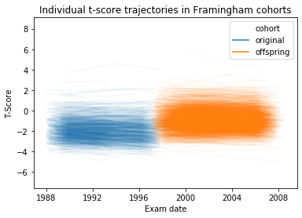

```python
sns.lineplot(data=full_data, x = 'scdt', y = 'tscore', units='newid', hue="cohort", estimator=None, alpha=0.05);
plt.xlabel('Exam date')
plt.ylabel('T-Score')
plt.title('Individual t-score trajectories in Framingham cohorts');
plt.legend();
```

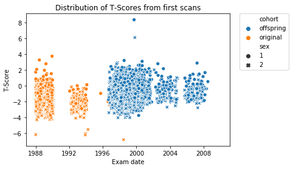

```python
indx=full_data.groupby('newid')['scdt'].idxmin()
first_scan = full_data.loc[indx,:]
first_scan['sex'] = first_scan['sex'].astype('category')
sns.scatterplot(data=first_scan, x="scdt", y="tscore", style="sex", hue='cohort');
plt.xlabel('Exam date'); plt.ylabel('T-Score')
plt.title('Distribution of T-Scores from first scans')
plt.legend(bbox_to_anchor=(1.05, 1), loc=2, borderaxespad=0.);
```

This plot is very interesting, in that is brings up some questions:

1. Some of the original cohort women are in very bad shape (t-score < -4), but almost noone in the offspring cohort is
2. The variability in the earliest scan of each cohort is far more variable than the subsequent rounds

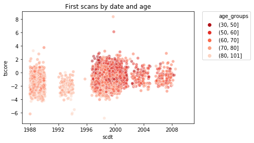

```python
first_scan.head()
sns.scatterplot(data=first_scan, x = 'scdt', y = 'tscore', hue='age_groups' , alpha=0.5,
               palette = 'Reds_r');
plt.title('First scans by date and age')
plt.legend(bbox_to_anchor=(1.05, 1), loc=2, borderaxespad=0.);
```